# Lecture Notes: Chapter 3 - A First Look at R

## Overview

- Introduction to the basic syntax of R
- Simple data analysis using the `mtcars` dataset
- The dataset contains information on different cars from the 1970s.

## 3.1 Understanding Data Frames

- Definition:
  - A two-dimensional data structure similar to a spreadsheet table.
  - Consists of rows (observations) and columns (variables).
- Key points:
  - **Rows**: Represent a single entity or observation.
    - In `mtcars`, each row represents a unique car model.
  - **Columns**: Represent a distinct attribute of an observation.
    - Example: `mpg` column for miles per gallon.
  - Data in columns must be of the same type, but columns can have different types.
- Loading the `mtcars` dataset:

  ```r
  data(mtcars)
  ```

## 3.2 Understanding the `$` Operator in R

- Used to access specific columns from a data frame.
  - Example:

  ```r
  mtcars$mpg
  ```

  ```
  ##  [1] 21.0 21.0 22.8 21.4 18.7 18.1 14.3 24.4 22.8 19.2 17.8 16.4 17.3 15.2 10.4
  ## [16] 10.4 14.7 32.4 30.4 33.9 21.5 15.5 15.2 13.3 19.2 27.3 26.0 30.4 15.8 19.7
  ## [31] 15.0 21.4
  ```

## 3.3 Summarizing the miles per gallon variable

- `summary()` function:
  - Provides statistical properties: min, 1st quartile, median, mean, 3rd quartile, max.
  - Usage:

  ```r
  mpg_summary <- summary(mtcars$mpg)
  ```

  - Display the result:

  ```r
  mpg_summary
  ```

  ```
  ##    Min. 1st Qu.  Median    Mean 3rd Qu.    Max.
  ##   10.40   15.43   19.20   20.09   22.80   33.90
  ```

## 3.3.1 Plotting miles per gallon vs horsepower

- Using the `plot()` function.
  - Example:

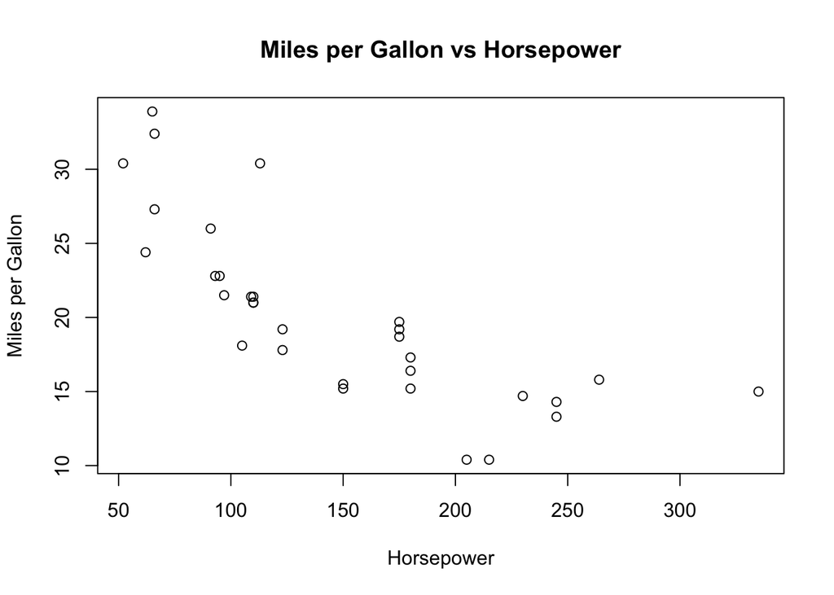

  ```r
  plot(x = mtcars$hp,
       y = mtcars$mpg,
       xlab = "Horsepower",
       ylab = "Miles per Gallon",
       main = "Miles per Gallon vs Horsepower")
  ```

- Parameters:
  - `xlab`: Label for the x-axis.
  - `ylab`: Label for the y-axis.
  - `main`: Main title of the plot.

## 3.4 Fitting a Trend Line

- Introduction to the `lm()` function for linear regression.
  - Example:

  ```r
  fit <- lm(mpg ~ hp, data = mtcars)
  ```

- Visualizing the trend line using the `abline()` function.
  - Example:

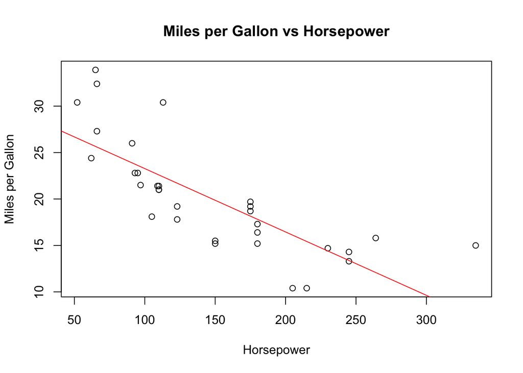

  ```r
  plot(x = mtcars$hp,
       y = mtcars$mpg,
       xlab = "Horsepower",
       ylab = "Miles per Gallon",
       main = "Miles per Gallon vs Horsepower")

  abline(fit, col="red")
  ```

## 3.5 Complete Chapter Example

- A recap of all the R code discussed in this chapter.

  ```r
  data(mtcars)
  mpg_summary <- summary(mtcars$mpg)
  mpg_summary
  ```

  ```
  ##    Min. 1st Qu.  Median    Mean 3rd Qu.    Max.
  ##   10.40   15.43   19.20   20.09   22.80   33.90
  ```

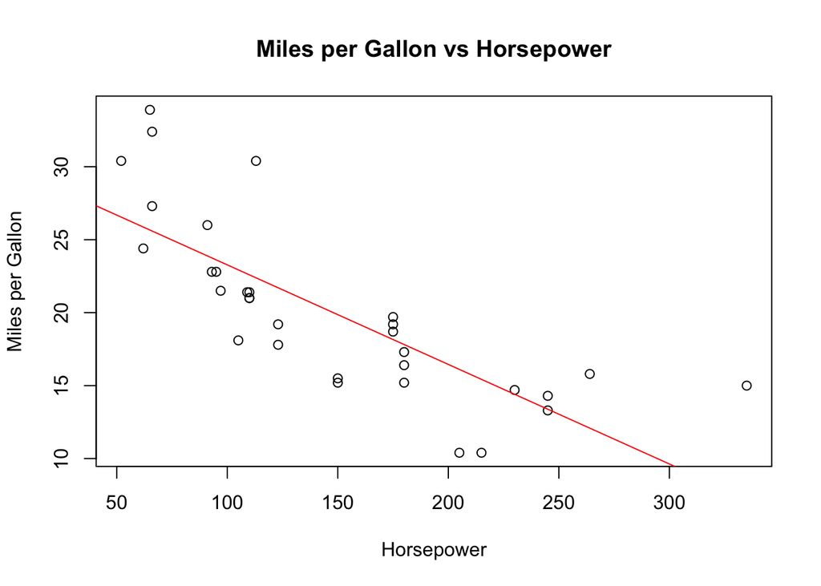

  ```r
  fit <- lm(mpg ~ hp, data = mtcars)
  plot(x = mtcars$hp,
       y = mtcars$mpg,
       xlab ="Horsepower",
       ylab = "Miles per Gallon",
       main = "Miles per Gallon vs Horsepower")
  abline(fit, col="red")
  ```

## Conclusion

- This chapter serves as an introduction to basic operations in R.
- These fundamentals will pave the way for more complex analyses in R.